# Risk Factor Analysis

## Outcome Variable

**Outcome Variable:** ever_co

## Predictor Variables

**Intervention Variable:** vagbrth

**Adjustment Set:**

unadjusted

## Stratifying Variables

The analysis was stratified on these variable(s):

- agecat
- studyid
- country

## Data Summary

| agecat | studyid | country | vagbrth | ever_co | n_cell | n | outcome_variable |
| --- | --- | --- | --- | --- | --- | --- | --- |
| 0-24 months | ki1000108-CMC-V-BCS-2002 | INDIA | 0 | 0 | 21 | 373 | ever_co |
| 0-24 months | ki1000108-CMC-V-BCS-2002 | INDIA | 0 | 1 | 4 | 373 | ever_co |
| 0-24 months | ki1000108-CMC-V-BCS-2002 | INDIA | 1 | 0 | 266 | 373 | ever_co |
| 0-24 months | ki1000108-CMC-V-BCS-2002 | INDIA | 1 | 1 | 82 | 373 | ever_co |
| 0-24 months | ki1000108-IRC | INDIA | 0 | 0 | 60 | 410 | ever_co |
| 0-24 months | ki1000108-IRC | INDIA | 0 | 1 | 10 | 410 | ever_co |
| 0-24 months | ki1000108-IRC | INDIA | 1 | 0 | 274 | 410 | ever_co |
| 0-24 months | ki1000108-IRC | INDIA | 1 | 1 | 66 | 410 | ever_co |
| 0-24 months | ki1017093b-PROVIDE | BANGLADESH | 0 | 0 | 144 | 700 | ever_co |
| 0-24 months | ki1017093b-PROVIDE | BANGLADESH | 0 | 1 | 16 | 700 | ever_co |
| 0-24 months | ki1017093b-PROVIDE | BANGLADESH | 1 | 0 | 466 | 700 | ever_co |
| 0-24 months | ki1017093b-PROVIDE | BANGLADESH | 1 | 1 | 74 | 700 | ever_co |
| 0-24 months | ki1017093c-NIH-Crypto | BANGLADESH | 0 | 0 | 189 | 500 | ever_co |
| 0-24 months | ki1017093c-NIH-Crypto | BANGLADESH | 0 | 1 | 15 | 500 | ever_co |
| 0-24 months | ki1017093c-NIH-Crypto | BANGLADESH | 1 | 0 | 259 | 500 | ever_co |
| 0-24 months | ki1017093c-NIH-Crypto | BANGLADESH | 1 | 1 | 37 | 500 | ever_co |
| 0-24 months | ki1066203-TanzaniaChild2 | TANZANIA, UNITED REPUBLIC OF | 0 | 0 | 203 | 2367 | ever_co |
| 0-24 months | ki1066203-TanzaniaChild2 | TANZANIA, UNITED REPUBLIC OF | 0 | 1 | 9 | 2367 | ever_co |
| 0-24 months | ki1066203-TanzaniaChild2 | TANZANIA, UNITED REPUBLIC OF | 1 | 0 | 2046 | 2367 | ever_co |
| 0-24 months | ki1066203-TanzaniaChild2 | TANZANIA, UNITED REPUBLIC OF | 1 | 1 | 109 | 2367 | ever_co |
| 0-24 months | ki1119695-PROBIT | BELARUS | 0 | 0 | 1948 | 16897 | ever_co |
| 0-24 months | ki1119695-PROBIT | BELARUS | 0 | 1 | 3 | 16897 | ever_co |
| 0-24 months | ki1119695-PROBIT | BELARUS | 1 | 0 | 14922 | 16897 | ever_co |
| 0-24 months | ki1119695-PROBIT | BELARUS | 1 | 1 | 24 | 16897 | ever_co |
| 0-24 months | ki1126311-ZVITAMBO | ZIMBABWE | 0 | 0 | 1130 | 13827 | ever_co |
| 0-24 months | ki1126311-ZVITAMBO | ZIMBABWE | 0 | 1 | 40 | 13827 | ever_co |
| 0-24 months | ki1126311-ZVITAMBO | ZIMBABWE | 1 | 0 | 12114 | 13827 | ever_co |
| 0-24 months | ki1126311-ZVITAMBO | ZIMBABWE | 1 | 1 | 543 | 13827 | ever_co |
| 0-24 months | kiGH5241-JiVitA-3 | BANGLADESH | 0 | 0 | 1402 | 26797 | ever_co |
| 0-24 months | kiGH5241-JiVitA-3 | BANGLADESH | 0 | 1 | 111 | 26797 | ever_co |

[output cut: 78 more lines]

The following strata were considered:

- agecat: 0-24 months, studyid: ki1000108-CMC-V-BCS-2002, country: INDIA
- agecat: 0-24 months, studyid: ki1000108-IRC, country: INDIA
- agecat: 0-24 months, studyid: ki1017093b-PROVIDE, country: BANGLADESH
- agecat: 0-24 months, studyid: ki1017093c-NIH-Crypto, country: BANGLADESH
- agecat: 0-24 months, studyid: ki1066203-TanzaniaChild2, country: TANZANIA, UNITED REPUBLIC OF
- agecat: 0-24 months, studyid: ki1119695-PROBIT, country: BELARUS
- agecat: 0-24 months, studyid: ki1126311-ZVITAMBO, country: ZIMBABWE
- agecat: 0-24 months, studyid: kiGH5241-JiVitA-3, country: BANGLADESH
- agecat: 0-24 months, studyid: kiGH5241-JiVitA-4, country: BANGLADESH
- agecat: 0-6 months, studyid: ki1000108-CMC-V-BCS-2002, country: INDIA
- agecat: 0-6 months, studyid: ki1000108-IRC, country: INDIA
- agecat: 0-6 months, studyid: ki1017093b-PROVIDE, country: BANGLADESH
- agecat: 0-6 months, studyid: ki1017093c-NIH-Crypto, country: BANGLADESH
- agecat: 0-6 months, studyid: ki1066203-TanzaniaChild2, country: TANZANIA, UNITED REPUBLIC OF
- agecat: 0-6 months, studyid: ki1119695-PROBIT, country: BELARUS
- agecat: 0-6 months, studyid: ki1126311-ZVITAMBO, country: ZIMBABWE
- agecat: 0-6 months, studyid: kiGH5241-JiVitA-3, country: BANGLADESH
- agecat: 0-6 months, studyid: kiGH5241-JiVitA-4, country: BANGLADESH
- agecat: 6-24 months, studyid: ki1000108-CMC-V-BCS-2002, country: INDIA
- agecat: 6-24 months, studyid: ki1000108-IRC, country: INDIA
- agecat: 6-24 months, studyid: ki1017093b-PROVIDE, country: BANGLADESH
- agecat: 6-24 months, studyid: ki1017093c-NIH-Crypto, country: BANGLADESH
- agecat: 6-24 months, studyid: ki1066203-TanzaniaChild2, country: TANZANIA, UNITED REPUBLIC OF
- agecat: 6-24 months, studyid: ki1119695-PROBIT, country: BELARUS
- agecat: 6-24 months, studyid: ki1126311-ZVITAMBO, country: ZIMBABWE
- agecat: 6-24 months, studyid: kiGH5241-JiVitA-3, country: BANGLADESH
- agecat: 6-24 months, studyid: kiGH5241-JiVitA-4, country: BANGLADESH

### Dropped Strata

Some strata were dropped due to rare outcomes:

- agecat: 0-24 months, studyid: ki1000108-CMC-V-BCS-2002, country: INDIA
- agecat: 0-24 months, studyid: ki1119695-PROBIT, country: BELARUS
- agecat: 0-6 months, studyid: ki1000108-CMC-V-BCS-2002, country: INDIA
- agecat: 0-6 months, studyid: ki1017093c-NIH-Crypto, country: BANGLADESH
- agecat: 0-6 months, studyid: ki1066203-TanzaniaChild2, country: TANZANIA, UNITED REPUBLIC OF
- agecat: 0-6 months, studyid: ki1119695-PROBIT, country: BELARUS
- agecat: 6-24 months, studyid: ki1000108-CMC-V-BCS-2002, country: INDIA
- agecat: 6-24 months, studyid: ki1119695-PROBIT, country: BELARUS

## Methods Detail

We’re interested in the causal parameters $E[Y_a]$ for all values of $a \in \mathcal{A}$. These parameters represent the mean outcome if, possibly contrary to fact, we intervened to set all units to have $A=a$. Under the randomization and positivity assumptions, these are identified by the statistical parameters $\psi_a=E_W[E_{Y|A,W}(Y|A=a,W)]$. In addition, we’re interested in the mean of $Y$, $E[Y]$ under no intervention (the observed mean). We will estimate these parameters by using SuperLearner to fit the relevant likelihood factors – $E_{Y|A,W}(Y|A=a,W)$ and $p(A=a|W)$, and then updating our likelihood fit using a joint TMLE.

For unadjusted analyses ($W=\{\}$), initial likelihoods were estimated using Lrnr_glm to estimate the simple $E(Y|A)$ and Lrnr_mean to estimate $p(A)$. For adjusted analyses, a small library containing Lrnr_glmnet, Lrnr_xgboost, and Lrnr_mean was used.

Having estimated these parameters, we will then use the delta method to estimate relative risks and attributable risks relative to a prespecified baseline level of $A$.

# Results Detail

## Results Plots

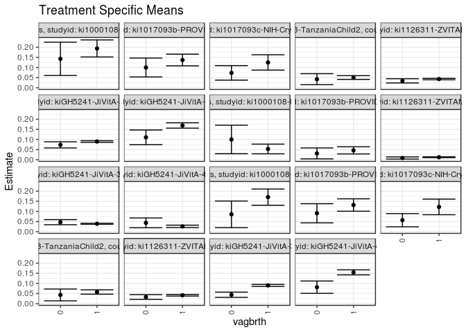

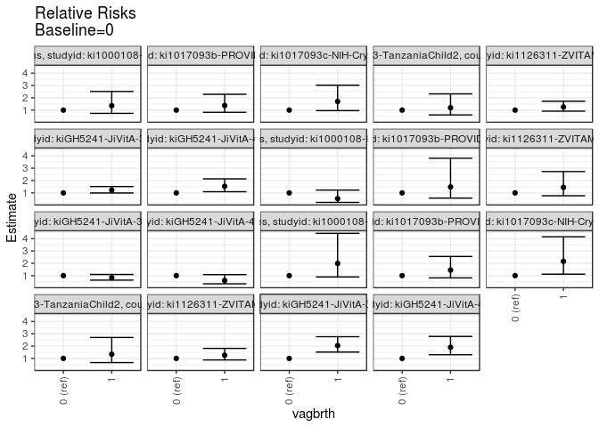

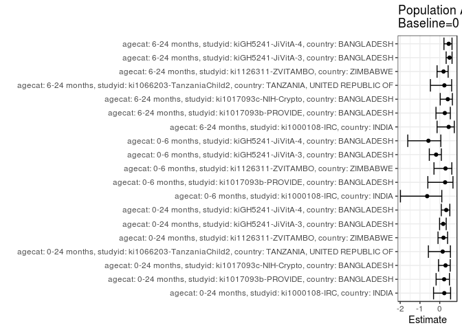

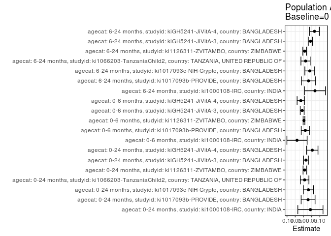

## Results Table

### Parameter: TSM

| agecat | studyid | country | intervention_level | baseline_level | estimate | ci_lower | ci_upper |
| --- | --- | --- | --- | --- | --- | --- | --- |
| 0-24 months | ki1000108-IRC | INDIA | 0 | NA | 0.1428571 | 0.0607829 | 0.2249314 |
| 0-24 months | ki1000108-IRC | INDIA | 1 | NA | 0.1941176 | 0.1520249 | 0.2362104 |
| 0-24 months | ki1017093b-PROVIDE | BANGLADESH | 0 | NA | 0.1000000 | 0.0534821 | 0.1465179 |
| 0-24 months | ki1017093b-PROVIDE | BANGLADESH | 1 | NA | 0.1370370 | 0.1080117 | 0.1660623 |
| 0-24 months | ki1017093c-NIH-Crypto | BANGLADESH | 0 | NA | 0.0735294 | 0.0376774 | 0.1093815 |
| 0-24 months | ki1017093c-NIH-Crypto | BANGLADESH | 1 | NA | 0.1250000 | 0.0872866 | 0.1627134 |
| 0-24 months | ki1066203-TanzaniaChild2 | TANZANIA, UNITED REPUBLIC OF | 0 | NA | 0.0424528 | 0.0153069 | 0.0695988 |
| 0-24 months | ki1066203-TanzaniaChild2 | TANZANIA, UNITED REPUBLIC OF | 1 | NA | 0.0505800 | 0.0413259 | 0.0598342 |
| 0-24 months | ki1126311-ZVITAMBO | ZIMBABWE | 0 | NA | 0.0341880 | 0.0237756 | 0.0446005 |
| 0-24 months | ki1126311-ZVITAMBO | ZIMBABWE | 1 | NA | 0.0429012 | 0.0393709 | 0.0464315 |
| 0-24 months | kiGH5241-JiVitA-3 | BANGLADESH | 0 | NA | 0.0733642 | 0.0581242 | 0.0886042 |
| 0-24 months | kiGH5241-JiVitA-3 | BANGLADESH | 1 | NA | 0.0898988 | 0.0858935 | 0.0939040 |
| 0-24 months | kiGH5241-JiVitA-4 | BANGLADESH | 0 | NA | 0.1105121 | 0.0742008 | 0.1468234 |
| 0-24 months | kiGH5241-JiVitA-4 | BANGLADESH | 1 | NA | 0.1691974 | 0.1560742 | 0.1823206 |
| 0-6 months | ki1000108-IRC | INDIA | 0 | NA | 0.1000000 | 0.0296358 | 0.1703642 |
| 0-6 months | ki1000108-IRC | INDIA | 1 | NA | 0.0530973 | 0.0291989 | 0.0769957 |
| 0-6 months | ki1017093b-PROVIDE | BANGLADESH | 0 | NA | 0.0312500 | 0.0042708 | 0.0582292 |
| 0-6 months | ki1017093b-PROVIDE | BANGLADESH | 1 | NA | 0.0462963 | 0.0285609 | 0.0640317 |
| 0-6 months | ki1126311-ZVITAMBO | ZIMBABWE | 0 | NA | 0.0085837 | 0.0032863 | 0.0138811 |
| 0-6 months | ki1126311-ZVITAMBO | ZIMBABWE | 1 | NA | 0.0124135 | 0.0104776 | 0.0143494 |
| 0-6 months | kiGH5241-JiVitA-3 | BANGLADESH | 0 | NA | 0.0470199 | 0.0344606 | 0.0595792 |
| 0-6 months | kiGH5241-JiVitA-3 | BANGLADESH | 1 | NA | 0.0392468 | 0.0367359 | 0.0417577 |
| 0-6 months | kiGH5241-JiVitA-4 | BANGLADESH | 0 | NA | 0.0435967 | 0.0193761 | 0.0678174 |
| 0-6 months | kiGH5241-JiVitA-4 | BANGLADESH | 1 | NA | 0.0262966 | 0.0203534 | 0.0322398 |
| 6-24 months | ki1000108-IRC | INDIA | 0 | NA | 0.0857143 | 0.0200549 | 0.1513737 |
| 6-24 months | ki1000108-IRC | INDIA | 1 | NA | 0.1705882 | 0.1305570 | 0.2106194 |
| 6-24 months | ki1017093b-PROVIDE | BANGLADESH | 0 | NA | 0.0909091 | 0.0437526 | 0.1380656 |
| 6-24 months | ki1017093b-PROVIDE | BANGLADESH | 1 | NA | 0.1316348 | 0.1010766 | 0.1621930 |
| 6-24 months | ki1017093c-NIH-Crypto | BANGLADESH | 0 | NA | 0.0567010 | 0.0241228 | 0.0892793 |
| 6-24 months | ki1017093c-NIH-Crypto | BANGLADESH | 1 | NA | 0.1223022 | 0.0837476 | 0.1608567 |
| 6-24 months | ki1066203-TanzaniaChild2 | TANZANIA, UNITED REPUBLIC OF | 0 | NA | 0.0430108 | 0.0138471 | 0.0721744 |
| 6-24 months | ki1066203-TanzaniaChild2 | TANZANIA, UNITED REPUBLIC OF | 1 | NA | 0.0574903 | 0.0467609 | 0.0682198 |
| 6-24 months | ki1126311-ZVITAMBO | ZIMBABWE | 0 | NA | 0.0329670 | 0.0213657 | 0.0445684 |
| 6-24 months | ki1126311-ZVITAMBO | ZIMBABWE | 1 | NA | 0.0414840 | 0.0375381 | 0.0454300 |
| 6-24 months | kiGH5241-JiVitA-3 | BANGLADESH | 0 | NA | 0.0440252 | 0.0311372 | 0.0569131 |
| 6-24 months | kiGH5241-JiVitA-3 | BANGLADESH | 1 | NA | 0.0899820 | 0.0850530 | 0.0949109 |
| 6-24 months | kiGH5241-JiVitA-4 | BANGLADESH | 0 | NA | 0.0813008 | 0.0509483 | 0.1116533 |
| 6-24 months | kiGH5241-JiVitA-4 | BANGLADESH | 1 | NA | 0.1545520 | 0.1420819 | 0.1670222 |

### Parameter: E(Y)

| agecat | studyid | country | intervention_level | baseline_level | estimate | ci_lower | ci_upper |
| --- | --- | --- | --- | --- | --- | --- | --- |
| 0-24 months | ki1000108-IRC | INDIA | NA | NA | 0.1853659 | 0.1477057 | 0.2230261 |
| 0-24 months | ki1017093b-PROVIDE | BANGLADESH | NA | NA | 0.1285714 | 0.1037574 | 0.1533855 |
| 0-24 months | ki1017093c-NIH-Crypto | BANGLADESH | NA | NA | 0.1040000 | 0.0772164 | 0.1307836 |
| 0-24 months | ki1066203-TanzaniaChild2 | TANZANIA, UNITED REPUBLIC OF | NA | NA | 0.0498521 | 0.0410826 | 0.0586217 |
| 0-24 months | ki1126311-ZVITAMBO | ZIMBABWE | NA | NA | 0.0421639 | 0.0388141 | 0.0455137 |
| 0-24 months | kiGH5241-JiVitA-3 | BANGLADESH | NA | NA | 0.0889652 | 0.0850582 | 0.0928722 |
| 0-24 months | kiGH5241-JiVitA-4 | BANGLADESH | NA | NA | 0.1643805 | 0.1517702 | 0.1769909 |
| 0-6 months | ki1000108-IRC | INDIA | NA | NA | 0.0611247 | 0.0378797 | 0.0843697 |
| 0-6 months | ki1017093b-PROVIDE | BANGLADESH | NA | NA | 0.0428571 | 0.0278427 | 0.0578716 |
| 0-6 months | ki1126311-ZVITAMBO | ZIMBABWE | NA | NA | 0.0120886 | 0.0102607 | 0.0139164 |
| 0-6 months | kiGH5241-JiVitA-3 | BANGLADESH | NA | NA | 0.0396858 | 0.0371902 | 0.0421814 |
| 0-6 months | kiGH5241-JiVitA-4 | BANGLADESH | NA | NA | 0.0277157 | 0.0217808 | 0.0336506 |
| 6-24 months | ki1000108-IRC | INDIA | NA | NA | 0.1560976 | 0.1209228 | 0.1912723 |
| 6-24 months | ki1017093b-PROVIDE | BANGLADESH | NA | NA | 0.1221498 | 0.0962275 | 0.1480722 |
| 6-24 months | ki1017093c-NIH-Crypto | BANGLADESH | NA | NA | 0.0953390 | 0.0688164 | 0.1218616 |
| 6-24 months | ki1066203-TanzaniaChild2 | TANZANIA, UNITED REPUBLIC OF | NA | NA | 0.0561404 | 0.0460367 | 0.0662440 |
| 6-24 months | ki1126311-ZVITAMBO | ZIMBABWE | NA | NA | 0.0407611 | 0.0370180 | 0.0445043 |
| 6-24 months | kiGH5241-JiVitA-3 | BANGLADESH | NA | NA | 0.0870071 | 0.0823429 | 0.0916713 |
| 6-24 months | kiGH5241-JiVitA-4 | BANGLADESH | NA | NA | 0.1485588 | 0.1367632 | 0.1603543 |

### Parameter: RR

| agecat | studyid | country | intervention_level | baseline_level | estimate | ci_lower | ci_upper |
| --- | --- | --- | --- | --- | --- | --- | --- |
| 0-24 months | ki1000108-IRC | INDIA | 0 | 0 | 1.0000000 | 1.0000000 | 1.000000 |
| 0-24 months | ki1000108-IRC | INDIA | 1 | 0 | 1.3588235 | 0.7353124 | 2.511043 |
| 0-24 months | ki1017093b-PROVIDE | BANGLADESH | 0 | 0 | 1.0000000 | 1.0000000 | 1.000000 |
| 0-24 months | ki1017093b-PROVIDE | BANGLADESH | 1 | 0 | 1.3703703 | 0.8219726 | 2.284644 |
| 0-24 months | ki1017093c-NIH-Crypto | BANGLADESH | 0 | 0 | 1.0000000 | 1.0000000 | 1.000000 |
| 0-24 months | ki1017093c-NIH-Crypto | BANGLADESH | 1 | 0 | 1.7000000 | 0.9581452 | 3.016244 |
| 0-24 months | ki1066203-TanzaniaChild2 | TANZANIA, UNITED REPUBLIC OF | 0 | 0 | 1.0000000 | 1.0000000 | 1.000000 |
| 0-24 months | ki1066203-TanzaniaChild2 | TANZANIA, UNITED REPUBLIC OF | 1 | 0 | 1.1914410 | 0.6126664 | 2.316973 |
| 0-24 months | ki1126311-ZVITAMBO | ZIMBABWE | 0 | 0 | 1.0000000 | 1.0000000 | 1.000000 |
| 0-24 months | ki1126311-ZVITAMBO | ZIMBABWE | 1 | 0 | 1.2548590 | 0.9153372 | 1.720318 |
| 0-24 months | kiGH5241-JiVitA-3 | BANGLADESH | 0 | 0 | 1.0000000 | 1.0000000 | 1.000000 |
| 0-24 months | kiGH5241-JiVitA-3 | BANGLADESH | 1 | 0 | 1.2253767 | 0.9920919 | 1.513517 |
| 0-24 months | kiGH5241-JiVitA-4 | BANGLADESH | 0 | 0 | 1.0000000 | 1.0000000 | 1.000000 |
| 0-24 months | kiGH5241-JiVitA-4 | BANGLADESH | 1 | 0 | 1.5310301 | 1.0967696 | 2.137234 |
| 0-6 months | ki1000108-IRC | INDIA | 0 | 0 | 1.0000000 | 1.0000000 | 1.000000 |
| 0-6 months | ki1000108-IRC | INDIA | 1 | 0 | 0.5309735 | 0.2303117 | 1.224136 |
| 0-6 months | ki1017093b-PROVIDE | BANGLADESH | 0 | 0 | 1.0000000 | 1.0000000 | 1.000000 |
| 0-6 months | ki1017093b-PROVIDE | BANGLADESH | 1 | 0 | 1.4814815 | 0.5761031 | 3.809713 |
| 0-6 months | ki1126311-ZVITAMBO | ZIMBABWE | 0 | 0 | 1.0000000 | 1.0000000 | 1.000000 |
| 0-6 months | ki1126311-ZVITAMBO | ZIMBABWE | 1 | 0 | 1.4461685 | 0.7651884 | 2.733188 |
| 0-6 months | kiGH5241-JiVitA-3 | BANGLADESH | 0 | 0 | 1.0000000 | 1.0000000 | 1.000000 |
| 0-6 months | kiGH5241-JiVitA-3 | BANGLADESH | 1 | 0 | 0.8346850 | 0.6357340 | 1.095897 |
| 0-6 months | kiGH5241-JiVitA-4 | BANGLADESH | 0 | 0 | 1.0000000 | 1.0000000 | 1.000000 |
| 0-6 months | kiGH5241-JiVitA-4 | BANGLADESH | 1 | 0 | 0.6031775 | 0.3361682 | 1.082265 |
| 6-24 months | ki1000108-IRC | INDIA | 0 | 0 | 1.0000000 | 1.0000000 | 1.000000 |
| 6-24 months | ki1000108-IRC | INDIA | 1 | 0 | 1.9901961 | 0.8932121 | 4.434423 |
| 6-24 months | ki1017093b-PROVIDE | BANGLADESH | 0 | 0 | 1.0000000 | 1.0000000 | 1.000000 |
| 6-24 months | ki1017093b-PROVIDE | BANGLADESH | 1 | 0 | 1.4479829 | 0.8202662 | 2.556066 |
| 6-24 months | ki1017093c-NIH-Crypto | BANGLADESH | 0 | 0 | 1.0000000 | 1.0000000 | 1.000000 |
| 6-24 months | ki1017093c-NIH-Crypto | BANGLADESH | 1 | 0 | 2.1569653 | 1.1200141 | 4.153965 |
| 6-24 months | ki1066203-TanzaniaChild2 | TANZANIA, UNITED REPUBLIC OF | 0 | 0 | 1.0000000 | 1.0000000 | 1.000000 |
| 6-24 months | ki1066203-TanzaniaChild2 | TANZANIA, UNITED REPUBLIC OF | 1 | 0 | 1.3366500 | 0.6615928 | 2.700503 |
| 6-24 months | ki1126311-ZVITAMBO | ZIMBABWE | 0 | 0 | 1.0000000 | 1.0000000 | 1.000000 |
| 6-24 months | ki1126311-ZVITAMBO | ZIMBABWE | 1 | 0 | 1.2583495 | 0.8739473 | 1.811829 |
| 6-24 months | kiGH5241-JiVitA-3 | BANGLADESH | 0 | 0 | 1.0000000 | 1.0000000 | 1.000000 |
| 6-24 months | kiGH5241-JiVitA-3 | BANGLADESH | 1 | 0 | 2.0438760 | 1.5129992 | 2.761025 |
| 6-24 months | kiGH5241-JiVitA-4 | BANGLADESH | 0 | 0 | 1.0000000 | 1.0000000 | 1.000000 |
| 6-24 months | kiGH5241-JiVitA-4 | BANGLADESH | 1 | 0 | 1.9009901 | 1.2981419 | 2.783797 |

### Parameter: PAR

| agecat | studyid | country | intervention_level | baseline_level | estimate | ci_lower | ci_upper |
| --- | --- | --- | --- | --- | --- | --- | --- |
| 0-24 months | ki1000108-IRC | INDIA | 0 | NA | 0.0425087 | -0.0340048 | 0.1190222 |
| 0-24 months | ki1017093b-PROVIDE | BANGLADESH | 0 | NA | 0.0285714 | -0.0137421 | 0.0708849 |
| 0-24 months | ki1017093c-NIH-Crypto | BANGLADESH | 0 | NA | 0.0304706 | -0.0004142 | 0.0613553 |
| 0-24 months | ki1066203-TanzaniaChild2 | TANZANIA, UNITED REPUBLIC OF | 0 | NA | 0.0073993 | -0.0187121 | 0.0335107 |
| 0-24 months | ki1126311-ZVITAMBO | ZIMBABWE | 0 | NA | 0.0079758 | -0.0020886 | 0.0180403 |
| 0-24 months | kiGH5241-JiVitA-3 | BANGLADESH | 0 | NA | 0.0156010 | 0.0008466 | 0.0303555 |
| 0-24 months | kiGH5241-JiVitA-4 | BANGLADESH | 0 | NA | 0.0538684 | 0.0190583 | 0.0886785 |
| 0-6 months | ki1000108-IRC | INDIA | 0 | NA | -0.0388753 | -0.1004926 | 0.0227420 |
| 0-6 months | ki1017093b-PROVIDE | BANGLADESH | 0 | NA | 0.0116071 | -0.0133041 | 0.0365183 |
| 0-6 months | ki1126311-ZVITAMBO | ZIMBABWE | 0 | NA | 0.0035049 | -0.0016568 | 0.0086665 |
| 0-6 months | kiGH5241-JiVitA-3 | BANGLADESH | 0 | NA | -0.0073341 | -0.0193314 | 0.0046633 |
| 0-6 months | kiGH5241-JiVitA-4 | BANGLADESH | 0 | NA | -0.0158810 | -0.0383911 | 0.0066290 |
| 6-24 months | ki1000108-IRC | INDIA | 0 | NA | 0.0703833 | 0.0065372 | 0.1342293 |
| 6-24 months | ki1017093b-PROVIDE | BANGLADESH | 0 | NA | 0.0312407 | -0.0118857 | 0.0743672 |
| 6-24 months | ki1017093c-NIH-Crypto | BANGLADESH | 0 | NA | 0.0386380 | 0.0087660 | 0.0685099 |
| 6-24 months | ki1066203-TanzaniaChild2 | TANZANIA, UNITED REPUBLIC OF | 0 | NA | 0.0131296 | -0.0150486 | 0.0413078 |
| 6-24 months | ki1126311-ZVITAMBO | ZIMBABWE | 0 | NA | 0.0077941 | -0.0034199 | 0.0190081 |
| 6-24 months | kiGH5241-JiVitA-3 | BANGLADESH | 0 | NA | 0.0429819 | 0.0298627 | 0.0561012 |
| 6-24 months | kiGH5241-JiVitA-4 | BANGLADESH | 0 | NA | 0.0672579 | 0.0372667 | 0.0972491 |

### Parameter: PAF

| agecat | studyid | country | intervention_level | baseline_level | estimate | ci_lower | ci_upper |
| --- | --- | --- | --- | --- | --- | --- | --- |
| 0-24 months | ki1000108-IRC | INDIA | 0 | NA | 0.2293233 | -0.3137534 | 0.5479041 |
| 0-24 months | ki1017093b-PROVIDE | BANGLADESH | 0 | NA | 0.2222222 | -0.1841711 | 0.4891462 |
| 0-24 months | ki1017093c-NIH-Crypto | BANGLADESH | 0 | NA | 0.2929864 | -0.0637892 | 0.5301060 |
| 0-24 months | ki1066203-TanzaniaChild2 | TANZANIA, UNITED REPUBLIC OF | 0 | NA | 0.1484250 | -0.5741345 | 0.5393151 |
| 0-24 months | ki1126311-ZVITAMBO | ZIMBABWE | 0 | NA | 0.1891630 | -0.0877959 | 0.3956067 |
| 0-24 months | kiGH5241-JiVitA-3 | BANGLADESH | 0 | NA | 0.1753608 | -0.0084990 | 0.3257011 |
| 0-24 months | kiGH5241-JiVitA-4 | BANGLADESH | 0 | NA | 0.3277055 | 0.0787981 | 0.5093585 |
| 0-6 months | ki1000108-IRC | INDIA | 0 | NA | -0.6360000 | -1.9871157 | 0.1039865 |
| 0-6 months | ki1017093b-PROVIDE | BANGLADESH | 0 | NA | 0.2708333 | -0.6021007 | 0.6681332 |
| 0-6 months | ki1126311-ZVITAMBO | ZIMBABWE | 0 | NA | 0.2899323 | -0.2915091 | 0.6096069 |
| 0-6 months | kiGH5241-JiVitA-3 | BANGLADESH | 0 | NA | -0.1848032 | -0.5275683 | 0.0810502 |
| 0-6 months | kiGH5241-JiVitA-4 | BANGLADESH | 0 | NA | -0.5729982 | -1.6171765 | 0.0545830 |
| 6-24 months | ki1000108-IRC | INDIA | 0 | NA | 0.4508929 | -0.1352628 | 0.7344063 |
| 6-24 months | ki1017093b-PROVIDE | BANGLADESH | 0 | NA | 0.2557575 | -0.1906948 | 0.5348120 |
| 6-24 months | ki1017093c-NIH-Crypto | BANGLADESH | 0 | NA | 0.4052692 | 0.0232668 | 0.6378697 |
| 6-24 months | ki1066203-TanzaniaChild2 | TANZANIA, UNITED REPUBLIC OF | 0 | NA | 0.2338709 | -0.4720286 | 0.6012620 |
| 6-24 months | ki1126311-ZVITAMBO | ZIMBABWE | 0 | NA | 0.1912138 | -0.1357484 | 0.4240493 |
| 6-24 months | kiGH5241-JiVitA-3 | BANGLADESH | 0 | NA | 0.4940050 | 0.3233528 | 0.6216182 |
| 6-24 months | kiGH5241-JiVitA-4 | BANGLADESH | 0 | NA | 0.4527363 | 0.2125952 | 0.6196397 |